# Longleaf Pine Species Diversity

Cody M Kent

January 24, 2019

#Longleaf Pine Data Analyis ##Introduction

1. This lab document goes with the provided R script that you will be working with
2. Before starting this lab you should have already created a csv file with the data that has been cleaned (e.g. outliers removed)
3. This csv file should be saved in a separate Data folder inside your Ecology Lab project
4. You should have a file titled LongleafpineScript_Student.R that contains most of the script for today’s analysis

##Loading and examining data First lets load in our data file and check it for anything that doesn’t make sense. Use the same commands we used last week to check out the data set, reminding yourself what each one does. Does everything look ok?

```r
Data<-read.csv('Data/Longleaf_Data.csv') #load in the data
head(Data) #look at the first few rows
tail(Data) #look at the last few rows
str(Data) #look at the structure of the data
summary(Data) #look at the summaries of each column
```

Lets check ourselves quick.

1. Look at each of these outputs?
2. Does everything look right?
3. Do you Understand what is in each row and where the data came from?

##Organizing Data For lab today, we will mostly be doing separate analysis on the two habitats. To make this simpler, lets divide the data into two groups, one for each habitat, using the subset function. The code for Longleaf pine is provided, you will need to add some code for Bayhead swamp.

```r
LL<-subset.data.frame(Data,Data$Habitat=='LL') #create a subset of data for Longleaf pine
BH<-  #Enter code here
```

##Preston Plots One way to understand species diversity patterns is with Preston plots. Read in your lab manual what a Preston plot is and think about how you would make one.

###Create bins As you should see, a Preston plot is basically a histogram with abundance categories on a log axis. Lets start with creating a vector of our abundance categories

```r
Bins<-c(0,1,2,4,8,16,32,64,128,256,512,1024,2048) # a vector containing our abundance categories
```

###Create data frame to hold data Next, for each of the sites we need to calculate how many species fall into each bin. Lets begin with generating an empty data frame to put the data in

```r
PrestonData<-data.frame(Min=Bins[-length(Bins)],Max=Bins[-1]) #Create a data frame with mins and maxes from the bins above
PrestonData$LL<-rep(NA) #Add some empty data for the Longleaf pine habitat
PrestonData$BH<-rep(NA)#Add some emtpy data for the Bayhead swamp habitat
PrestonData$Name<-paste(PrestonData$Min,PrestonData$Max,sep='-') #Add a name for each bin
PrestonData
```

```
##     Min  Max LL BH      Name
## 1     0    1 NA NA       0-1
## 2     1    2 NA NA       1-2
## 3     2    4 NA NA       2-4
## 4     4    8 NA NA       4-8
## 5     8   16 NA NA      8-16
## 6    16   32 NA NA     16-32
## 7    32   64 NA NA     32-64
## 8    64  128 NA NA    64-128
## 9   128  256 NA NA   128-256
## 10  256  512 NA NA   256-512
## 11  512 1024 NA NA  512-1024
## 12 1024 2048 NA NA 1024-2048
```

Look at the data frame we created and make sure you understand it. Next, think about how we can fill in those missing numbers. Here we are going to write a function to count the number of species that belong in each bin. The function is written for you, but make sure you understand how it is working

```r
count.bin<-function(X,Min,Max){
  Number<-sum(X>Min & X<Max) #Count the number of cases where X is greater than the min and less than the max
  Number<-Number+sum(X==Min)/2 #Add in the number of cases where X is equal to the minimum devided by two
  Number<-Number+sum(X==Max)/2 #do the same thing for X equals the maximum
  return(Number) #return the total number
}
```

Now, lets use this function to populate the data frame. We are going to use something called a for loop for this. Basically what we are doing is going through each row and calculating the number of species that belong in that bin.

```r
for(r in 1:nrow(PrestonData)){
  #calculate the number of species in the bin for each row (r) of the data frame
  PrestonData$LL[r]<-count.bin(X=LL$Count,Min=PrestonData$Min[r],Max = PrestonData$Max[r])
  PrestonData$BH[r]<-count.bin(X=BH$Count,Min=PrestonData$Min[r],Max = PrestonData$Max[r]) #do the same for Bayhead swamp
}
PrestonData
```

```
##     Min  Max   LL  BH      Name
## 1     0    1  3.5 4.0       0-1
## 2     1    2  4.5 5.5       1-2
## 3     2    4  4.5 5.0       2-4
## 4     4    8  5.5 5.5       4-8
## 5     8   16  7.0 3.5      8-16
## 6    16   32 13.0 2.5     16-32
## 7    32   64 11.0 3.0     32-64
## 8    64  128  8.5 2.0    64-128
## 9   128  256  7.5 0.0   128-256
## 10  256  512  9.0 0.0   256-512
## 11  512 1024  4.0 0.0  512-1024
## 12 1024 2048  0.0 0.0 1024-2048
```

Check the output. Does this data table look how you expected it to? If so, we can go on to generate the graphs.

###Making the figure To do this we will be using the `barplot()` function. The final output should look something like the figure below.

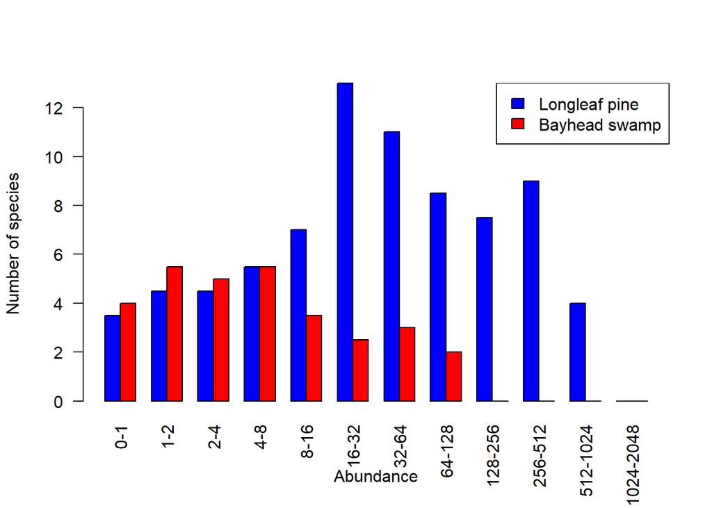

```r
#Here we make a barplot for the Lonleaf data. Lets break down each step
barplot(height=rbind(PrestonData$LL,PrestonData$BH), #The heights of the bars come form the PrestonData LL and BH columns
        names.arg=PrestonData$Name, #The names for the x axis lables come form PrestonData$Names
        col=c('Blue','Red'), #Set the colors for the bars
        las=2, #Rotate the x axis labels vertically
        beside=T, #place the bars beside eachother (default is stacked)
        xlab='Abundance',#add the x axis name
        ylab='Number of species') #add the y axis name
legend('topright',legend=c('Longleaf pine','Bayhead swamp'),fill=c('Blue','Red')) #make a legend for the graph
```

How would you interpret this graph you have made?

##Species Accumulation Curves Another way to understand species diversity patterns is with species accumulation curves. Read in your lab manual what a Preston plot is and think about how you would make one.

Before starting, think to yourself about how you could make a species accumulation curve from our data.

###Create a data frame We are going to start this the same way we did the Preston plots, by creating a data frame to hold our data.

```r
AccumData<-data.frame(
  #Lets make a column called group that goes from group 1 to the number of groups we have
  Group=seq(from=1,to=max(max(BH$Group,LL$Group)),by=1),
  LL=rep(NA),BH=rep(NA)) #put in placeholders for LL and BH
AccumData
```

```
##   Group LL BH
## 1     1 NA NA
## 2     2 NA NA
## 3     3 NA NA
## 4     4 NA NA
## 5     5 NA NA
## 6     6 NA NA
## 7     7 NA NA
## 8     8 NA NA
## 9     9 NA NA
```

Look at this data frame you created. Does it make sense? Now, how would you calculate the values that go into each cell?

```r
for(r in 1:nrow(AccumData)){
  #for each row, the value is the number of groups that are equal to or less than the group of intrest
  AccumData$LL[r]<-sum(LL$Group<=AccumData$Group[r])
  AccumData$BH[r]<-sum(BH$Group<=AccumData$Group[r]) #do it agaoin for Bayhead swamp
}
```

Look at the data frame now to make sure it looks right.

###Making the figure Now lets make the plot. Here we can just use the `plot()` function to make an empty plot and then the `points()` function to add in the data from the two habitats.

```r
#first we will make an empty plot
plot(y=c(0,max(c(AccumData$LL,AccumData$BH))), #the y axis should go from 0 to the largest value
     x=c(1,max(AccumData$Group)), #the x axis should go form 1 to the largest value
     type='n', #tell R not to actually plot anything
     ylab='Number of species',xlab='Number of groups') #set x and y axis labels
#now we will ad the points for Longleaf pine
points(LL~Group, #Plot the data from LL against the group number
       data=AccumData, #tell R where to get the data
       type='o',# Make it be points connected by lines
       pch=16,col='blue') #set the shape (pch) and collor
```

Now use the `points()` function to add the data from Bayhead swamp to the same graph. Also, use the `legend()` function to add an appropriate legend. You should end up with a plot similar to the one below. Hint, you will have to use the `lty=` and `pch=` arguments in `legend()`.

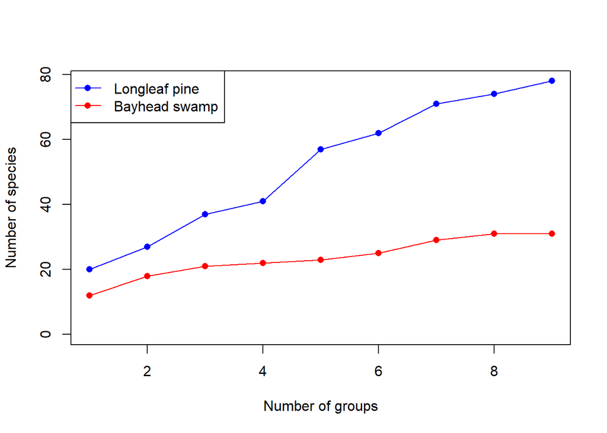

How can you interpret the figure you made?

##Shannon’s Diversity We will now calculate Shannon’s diversity, one common metric of species diversity

Shannon’s diversity will be based off of a series of calculations provided in the lab manual. A framework for doing the calculations is provided, but you will need to fill them in.

###Calculate pi You will start with calculating p for each morphospecies in each habitat

```r
LL_pi<- #calulate p(i) for each species (i)
BH_pi<- #do the same for Bayhead swamp
```

###Calculate Shannon’s Diversity Next you will calculate Shannon’s diversity (H’) for each habitat

```r
LL_H<- #calculate Shannon's diversity for LL
BH_H<- #do the same for Bayhead swamp
LL_H
BH_H
```

Which habitat was more diverse?

###Calculate Eveness Shannon’s diversity also comes with an evenness score. Calculate that next

```r
LL_E<- #calculate Shannon's evenness for LL
BH_E<- #do the same for Bayhead swamp
LL_E
BH_E
```

Which habitat was more even?

###Perform t-test Next, as you see in your lab manual, we are going to test if these habitats differ in diversity using a modified t-test. Like any t-test you will have to calculate a few different things. First, lets calculate the variance for each habitat.

```r
LL_v<- #calculate variance for LL
BH_v<- #do the same for Bayhead swamp
LL_v
BH_v
```

Next calculate the t value.

```r
t<-abs() #calculate t
t
```

Next lets calculate the degrees of freedom

```r
df<- #calculate df
df
```

Lastly, lets calculate a p-value. The forumal as been provided to you and is the same as we used in the last lab.

```r
p<-2*pt(t,df,lower.tail=F)
```

How would you interpret these results?

##Simpson’s diversity A second way to compare species diversity is with Simpson’s index. Use your lab manual and r script as a guide to calculate these values

Fist, lets calculate the values N and n for each habitat

```r
LL_N<- #calculate N for Longleaf pine
LL_n<- #calculate n for Longleaf pine
BH_N<- #do the same for Bayhead swamp
BH_n<-
```

Now use these numbers to calculate Simpson’s diversity (Ds) for each habitat.

```r
LL_Ds<- #calculate Ds for Longleaf pine
BH_Ds<- #do the same for Bayhead swamp
LL_Ds
BH_Ds
```

How would you interpret these results?

Simpson’s index also comes with an evenness score. Calculate that (Ed)

```r
LL_Ed<- #calculate Ed for Longleaf pine
BH_Ed<- #do the same for Bayhead swamp
LL_Ed
BH_Ed
```

We won’t be doing a t-test for Simpson’s diversity, so your done with calculations. How would you interpret these results?